# Lecture 3

Temporal Models and Smoothing

Sara Martino

sara.martino@ntnu.no

Dept. of Mathematical Science, NTNU

Janine Illian

Janine.Illian@glasgow.ac.uk

University of Glasgow

Jafet Belmont

Jafet.Belmont@glasgow.ac.uk

University of Glasgow

# Temporal models and smoothing

## Motivation

Data are often observed in time, and time dependence is often expected.

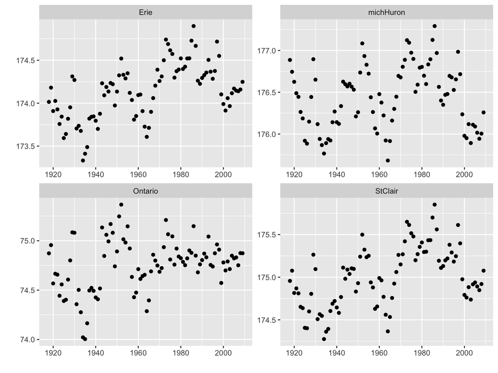

- Observations are correlated in time

## Motivation

1. Smoothing of the time effect

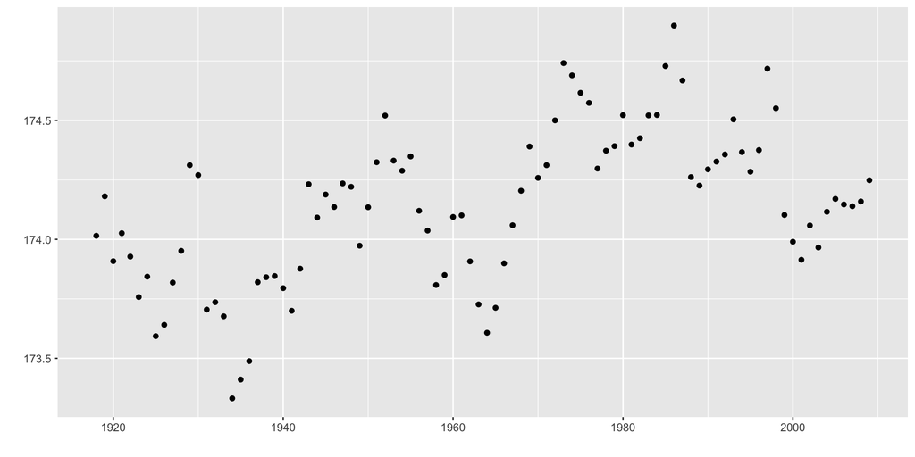

## What is our goal?

1. Smoothing of the time effect

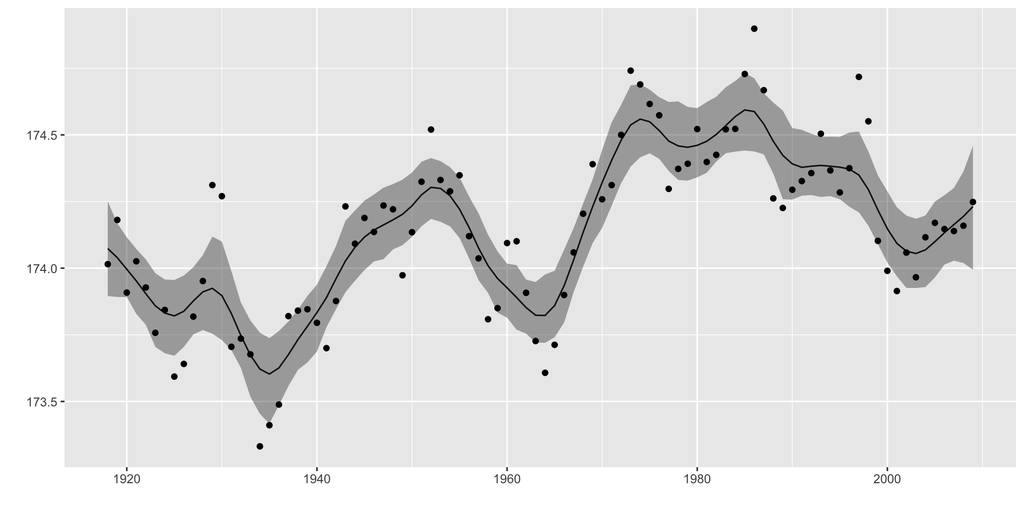

**Note:** We can use the same model to smooth covariate effects!

## What is our goal?

1. Smoothing of the time effect
2. Prediction

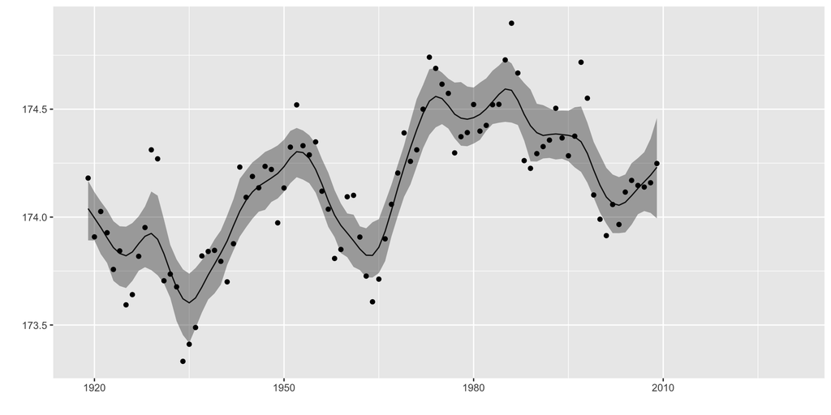

We can “predict” any unobserved data, not only future data, e.g. gaps in the data etc.

## Modelling time with INLA

Time can be indexed over a

- Discrete domain (e.g., years)
- Continuous domain

## Modelling time with INLA

Time can be indexed over a

- Discrete domain (e.g., years)
  - Main models: RW1, RW2 and AR1
  - **Note:** RW1 and RW2 are also used for smoothing covariates
- Continuous domain
  - Here we use the so-called SPDE-approach (more on this later)

# Discrete time modelling

## Example - Height of Lake Erie in time

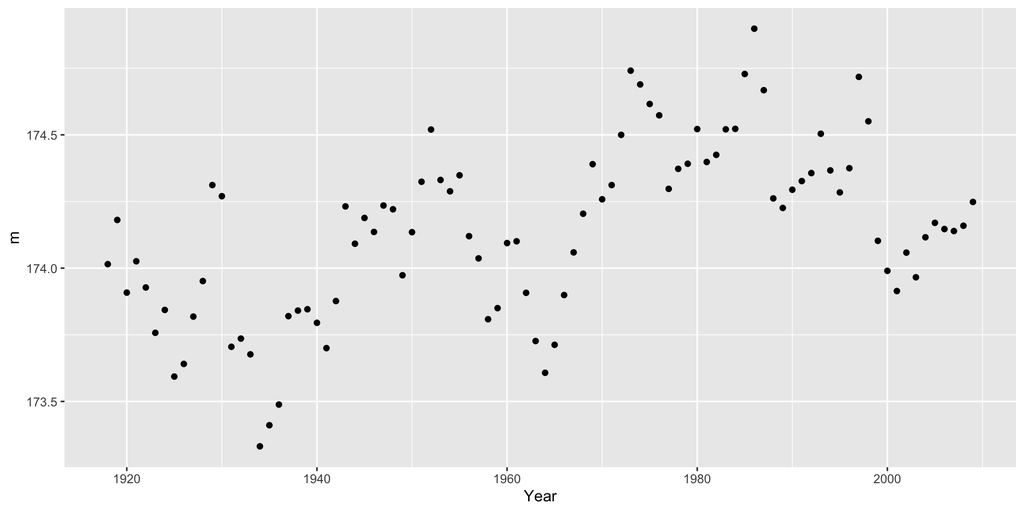

**Goal** we want understand the pattern and predict into the future

## Random Walk models

Random walk models encourage the mean of the linear predictor to vary gradually over time.

They do this by assuming that, on average, the time effect at each point is the mean of the effect at the neighbouring points.

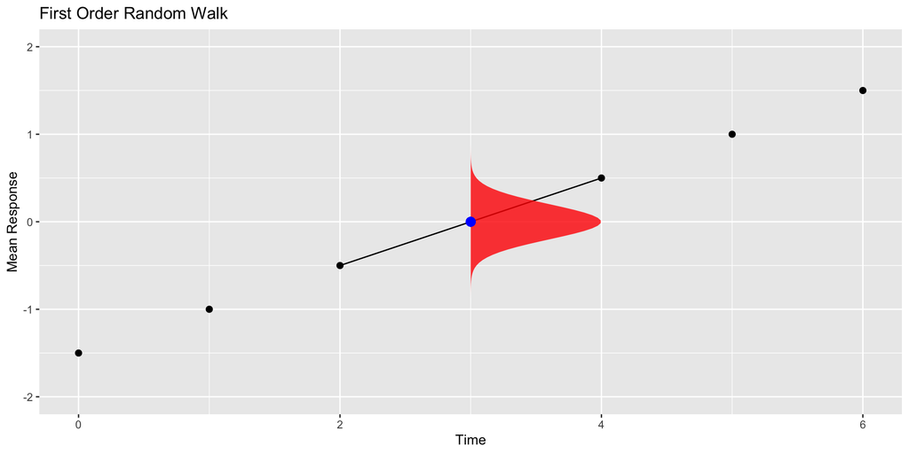

- Random Walk of order 1 (RW1) we take the two nearest neighbours
- Random Walk of order 2 (RW2) we take the four nearest neighbours

## Random walks of order 1

**Idea:** $\longrightarrow\ u_t = \text{mean}(u_{t-1} , u_{t+1}) + \text{Gaussian error with precision } \tau$

**Definition**

$$\pi(\mathbf{u} \mid \tau) \propto
\exp\!\left(
-\frac{\tau}{2} \sum_{t=1}^{T-1} (u_{t+1} - u_t)^2
\right) = \exp\!\left(-\tfrac{1}{2} \, \mathbf{u}^{\top} \mathbf{Q}\ \mathbf{u}\right)$$

$$\mathbf{Q} = \tau
\begin{bmatrix}
1 & -1 & & & & \\
-1 & 2 & -1 & & & \\
& & \ddots & \ddots & \ddots & \\
& & & -1 & 2 & -1 \\
& & & & -1 & 1
\end{bmatrix}$$

## Random walks of order 1

**Idea:** $\longrightarrow\ u_t = \text{mean}(u_{t-1} , u_{t+1}) + \text{Gaussian error with precision } \tau$

**Definition**

$$\pi(\mathbf{u} \mid \tau) \propto
\exp\!\left(
-\frac{\tau}{2} \sum_{t=1}^{T-1} (u_{t+1} - u_t)^2
\right) = \exp\!\left(-\tfrac{1}{2} \, \mathbf{u}^{\top} \mathbf{Q}\ \mathbf{u}\right)$$

Important things to understand (not just for RW1 mdoels!):

1. **The (sparse) precision matrix**
2. Role of the precision parameter $\tau$ and prior distribution
3. RW as intrinsic model

## The precision matrix and GMRF

(A more theoretical interlude 📚 🤔)

We have talked about the **precision** matrix $\mathbf{Q}$ but…

- what is it?
- why we will keep talking about it?
- What does it have to do the GMRF (and what are they)?

Let’s start at the beginning 😃

A **Gaussian distribution** $\mathbf{u}\sim\mathcal{N}(0,\Sigma)$ is controlled by:

— The mean vector $\mu$, which we have set equal to 0. This is the centre of the distribution — The matrix $\Sigma$ describes all pairwise covariances $\Sigma_{ij} = \text{Cov}(u_i, u_j)$

Formally

$$\pi(\mathbf{u}) = \frac{1}{2\pi|\Sigma|^{1/2}}\exp\left\{-\frac{1}{2}\mathbf{u}^T\Sigma^{-1}\mathbf{u}\right\}$$

The **precision matrix** is inverse of the **covariance matrix**

$$\mathbf{Q} = \mathbf{\Sigma}^{-1}$$

## The Gaussian distribution

| Advantages 😄👍 | Disadvantages 😔👎 |
| --- | --- |
| **mostly theoretical** | **mostly computational** |
| Analytically tractable. | $\Sigma$ usually is large and **dense** |
| We have a good understanding of its properties. | Computations scale as $\mathcal{O}(n^3)$ |
| Basically, it’s easy to do the theory | Not feasible for large problems |

We need to reduce the computational burden !

This can be done by using **sparse** matrices, ie matrices where a lot of entries are exactly zero!!

## Two possible options

So…which matrix should be sparse? 🤔

$$\mathcal{u}\sim\mathcal{N}(0,\Sigma)$$

1. Force the *covariance* matrix $\Sigma$ to be sparse
2. Force the *precision* matrix $\Sigma^{-1}$ to be sparse

## Two possible options

$$\mathcal{u}\sim\mathcal{N}(0,\Sigma)$$

1. Force the *covariance* matrix $\Sigma$ to be sparse
   - $\Sigma_{ij} = \text{Cov}(u_i, u_j)$ : Covariance between $u_i$ and $u_j$
   - $\Sigma_{ij} = 0$ $\longrightarrow$ $u_i$ and $u_j$ are *independent*
   - A sparse covariance matrix implies that many elements of $\mathbf{u}$ are mutually independent…..is this desirable?
2. Force the *precision* matrix $\mathbf{Q} = \Sigma^{-1}$ to be sparse

## Two possible options

$$\mathcal{u}\sim\mathcal{N}(0,\Sigma)$$

1. Force the *covariance* matrix $\Sigma$ to be sparse
   - $\Sigma_{ij} = \text{Cov}(u_i, u_j)$ : Covariance between $u_i$ and $u_j$
   - $\Sigma_{ij} = 0$ $\longrightarrow$ $u_i$ and $u_j$ are *independent*
   - A sparse covariance matrix implies that many elements of $\mathbf{u}$ are mutually independent…..is this desirable?
2. Force the *precision* matrix $\mathbf{Q} = \Sigma^{-1}$ to be sparse
   - What does $Q_{ij}$ represents?
   - What does a sparse precision matrix implies?

## What does $Q_{ij}$ represents?

$Q_{ij}$ is an element of the precision matrix

It represents the strength of *conditional dependence* between variables $i$ and $j$

- $Q_{ij}= 0$ variables $i$ and $j$ are *conditionally* independent *given* all other variables.
- $Q_{ij}\neq 0$ variables $i$ and $j$ are conditionally dependent.

It is useful to represent the conditional independence structure through a graph

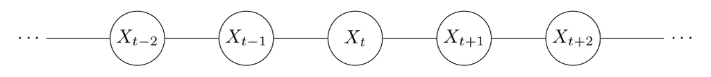

## Conditional independence and the precision matrix

**Theorem**: $u_i\perp u_j|\mathbf{u}_{-ij}\Longleftrightarrow Q{ij} =0$

This is the key property! 😃

## (Informal) definition of a GMRF

A **GMRF** is a Gaussian distribution where the non-zero elements of the precision matrix are defined by the graph structure.

In the RW1 example the precision matrix is tridiagonal since each variable is connected only to its predecessor and successor.

$$\mathbf{Q} = \tau \begin{bmatrix}
1& -1 & 0 & 0 &\dots& 0 \\
-1 & 2& -1 & 0 & \dots& 0 \\
0 & -1 & 2 &-1 & \dots& 0 \\
0 & 0 & -1 &2 & \dots & \dots \\
\dots& \dots& \dots& \dots& \dots& \dots& \\
0 &0 & 0 & \dots & -1& 1\\
\end{bmatrix}$$

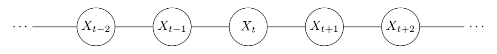

## GMRF and INLA

- Every component of the *latent Gaussian* field $\mathbf{u}$ in an INLA model is always a GMRF!!
- We will see how the idea of GMRF expands also for continuously indexed processes (SPDE approach)

## Random walks of order 1

**Idea:** $\longrightarrow\ u_t = \text{mean}(u_{t-1} , u_{t+1}) + \text{Gaussian error with precision } \tau$

**Definition**

$$\pi(\mathbf{u} \mid \tau) \propto
\exp\!\left(
-\frac{\tau}{2} \sum_{t=1}^{T-1} (u_{t+1} - u_t)^2
\right) = \exp\!\left(-\tfrac{1}{2} \, \mathbf{u}^{\top} \mathbf{Q}\ \mathbf{u}\right)$$

Important things to understand (not just for RW1 mdoels!):

1. The (sparse) precision matrix
2. **Role of the precision parameter $\tau$ and prior distribution**
3. RW as intrinsic model

## What is the role of the precision parameter?

- $\tau$ says how much $u_t$ can vary around its mean
  - Small $\tau$ $\rightarrow$ large variation $\rightarrow$ less smooth effect
  - Large $\tau$ $\rightarrow$ small variation $\rightarrow$ smoother effect

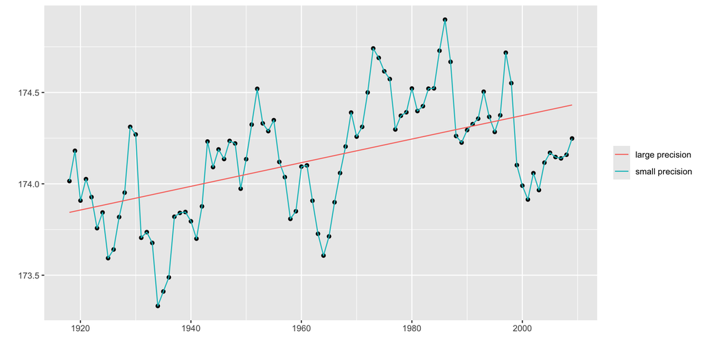

We need to set a *prior distribution* for $\tau$.

A common option is the so called *PC-priors*

## Penalized Complexity (PC) priors

- PC priors are easily available in `inlabru` for many model parameters
- They are built with two principles in mind:
  1. The prior **discourages overdispersion** by penalizing deviation from a *base model*

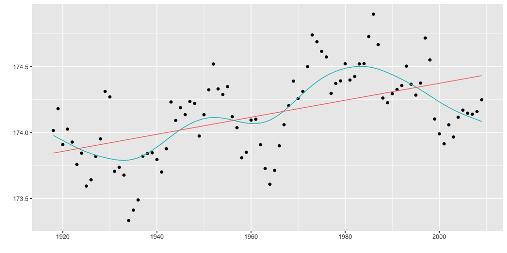

- A line is the *base model*
- We want to penalize more complex models

## Penalized Complexity (PC) priors

- PC prior are easily available in `inlabru` for many model parameters
- They are built with two principle in mind:
  1. The prior **discourages overdispersion** by penalizing deviation from a *base model*
  2. **User-defined** scaling

$$\begin{eqnarray}
\sigma = \sqrt{1/\tau} \\
\text{Prob}(\sigma>U) = \alpha;\\ \qquad U>0, \ \alpha \in (0,1)
\end{eqnarray}$$

- $U$ an upper limit for the standard deviation and $\alpha$ a small probability.
- $U$ a likely value for the standard deviation and $\alpha=0.5$.

## Example

**The Model**

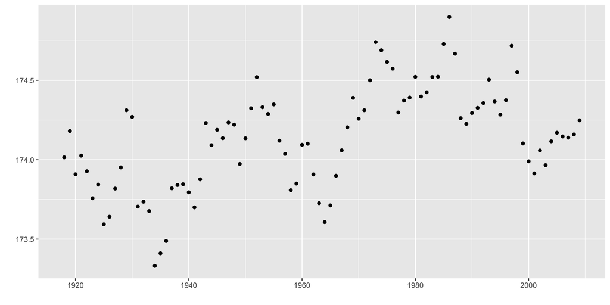

**The code**

```r
cmp = ~ Intercept(1) +
  time(year, model = "rw1",
       hyper = list(prec =
                      list(prior = "pc.prec",
                           param = c(0.5, 0.5))))
```

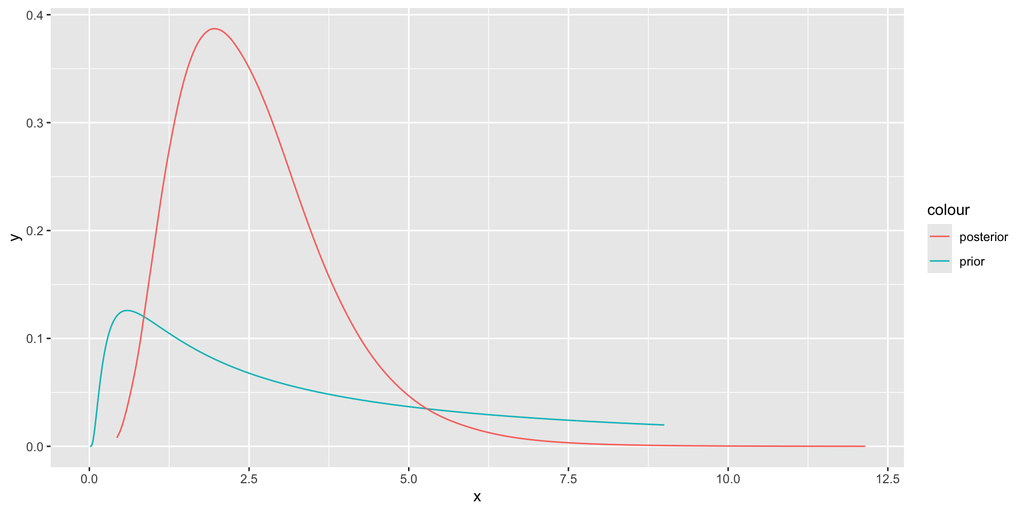

## Random walks of order 1

**Idea:** $\longrightarrow\ u_t = \text{mean}(u_{t-1} , u_{t+1}) + \text{Gaussian error with precision } \tau$

**Definition**

$$\pi(\mathbf{u} \mid \tau) \propto
\exp\!\left(
-\frac{\tau}{2} \sum_{t=1}^{T-1} (u_{t+1} - u_t)^2
\right) = \exp\!\left(-\tfrac{1}{2} \, \mathbf{u}^{\top} \mathbf{Q}\ \mathbf{u}\right)$$

Important things to understand (not just for RW1 models!):

1. The (sparse) precision matrix
2. Role of the precision parameter $\tau$ and prior distribution
3. **RW as intrinsic model**

## RW as intrinsic models

RW1 defines *differences*, not *absolute levels*:

- Only the *changes* between neighbouring terms are modelled.
- Mathematically,
  $$(u_1,\dots,u_n)\text{ and }(u_1+a,\dots,u_n+a)$$
  produce identical likelihoods — they’re indistinguishable.

This means:

- If $u_t\sim\text{RW}1$ then
  $$\begin{aligned}
  \eta_t & = \beta_0 + u_t \\
  & =(\beta_0+k) + (u_t-k) \\
  & = \beta_0^* + u_t^*
  \end{aligned}$$

so parameters are not well-defined.

**Solution:**

- Sum to zero constraint $\sum_{i = 1}^n u_i = 0$
- This is included in the model by default

## RW as intrinsic models

```r
cmp1 = ~ Intercept(1) + time(year, model = "rw1", constr = TRUE)
cmp2 = ~ Intercept(1) + time(year, model = "rw1", constr = FALSE)
lik = bru_obs(formula = Erie~.,
              data = lakes)

fit1 = bru(cmp1,lik)
fit2 = bru(cmp2,lik)
```

```
[1] "FIT1 - Intercept"
```

```
             mean    sd 0.025quant 0.5quant 0.975quant    mode   kld
Intercept 174.138 0.002    174.135  174.138    174.142 174.138 0.002
```

```
[1] "FIT2 - Intercept"
```

```
          mean     sd 0.025quant 0.5quant 0.975quant mode kld
Intercept    0 31.623    -62.009        0     62.009    0   0
```

```
[1] "FIT1 - RW1 effect"
```

[output not shown]

```
[1] "FIT2 - RW1 effect"
```

```
    ID    mean     sd 0.025quant 0.5quant 0.975quant    mode kld
1 1918 174.016 31.623    112.008  174.016    236.025 174.016   0
2 1919 174.177 31.623    112.168  174.177    236.186 174.177   0
```

## Random walks of order 2

- Just like RW1, but now we consider 4 neighbours instead of 2

$$u_t = \text{mean}(u_{t-2} ,u_{t-1} , u_{t+1}, u_{t+2} ) + \text{some Gaussian error with precision } \tau$$

- RW2 are smoother than RW1
- The precision has the same role as for RW1

## Example

```r
cmp1 = ~ Intercept(1) +
  time(year, model = "rw1",
       scale.model = T,
       hyper = list(prec =
                      list(prior = "pc.prec",
                           param = c(0.3,0.5))))

cmp2 = ~ Intercept(1) +
  time(year, model = "rw2",
       scale.model = T,
       hyper = list(prec =
                      list(prior = "pc.prec",
                           param = c(0.3,0.5))))


lik = bru_obs(formula = Erie~ .,
              data = lakes)

fit1 = bru(cmp1, lik)
fit2 = bru(cmp2, lik)
```

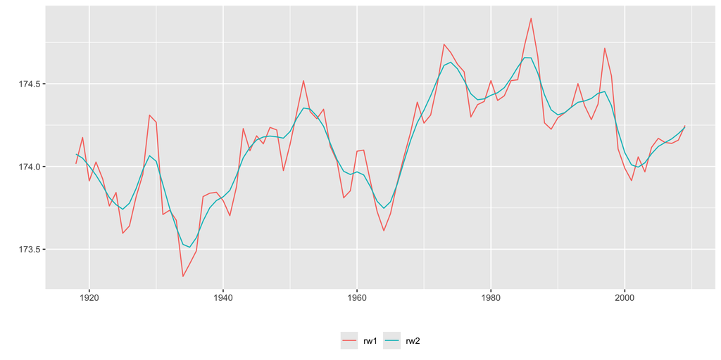

**NOTE:** the `scale.model = TRUE` option scales the $\mathbf{Q}$ matrix so the precision parameter has the same interpretation in both models.

## RW models as smoothers for covariates

- RW models are discrete models
- Covariates are often recorded as continuous values
- The function `inla.group()` will bin covariate values into groups (default 25 groups)

> `inla.group(x, n = 25, method = c("cut", "quantile"))`
- Two ways to bin
  - `cut` (default) splits the data using equal length intervals
  - `quantile` uses equi-distant quantiles in the probability space.

## RW models as smoothers for covariates - Example

The data are derived from an anthropometric study of 892 females under 50 years in three Gambian villages in West Africa.

`Age` - Age of respondent (continuous)

`triceps` - Triceps skinfold thickness.

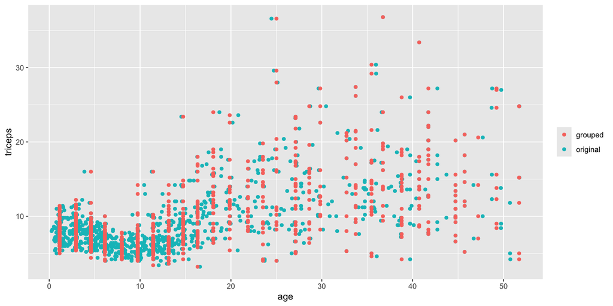

```r
triceps$age_group = inla.group(triceps$age, n = 30)
```

## Model fit and results

```r
cmp = ~ Intercept(1) + cov(age_group, model = "rw2", scale.model =T)
lik = bru_obs(formula = triceps ~.,
              data = triceps)

fit = bru(cmp, lik)
pred = predict(fit, triceps, ~ Intercept + cov)
```

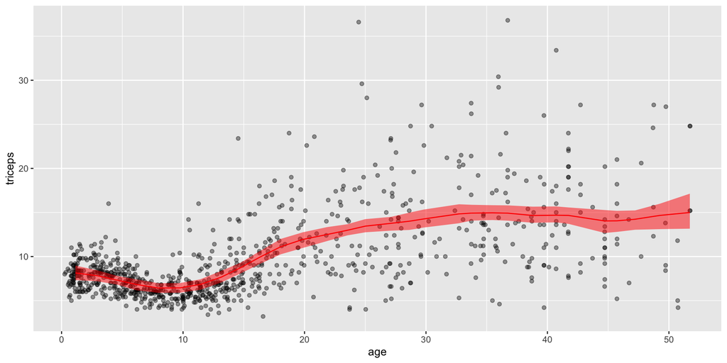

## Summary RW (1 and 2) models

- Latent effects suitable for smoothing and modelling temporal data.
- One hyperparameter: the precision $\tau$
  - Use PC prior for $\tau$
- It is an *intrinsic* model
  - The precision matrix $\mathbf{Q}$ is rank deficient
  - A sum-to-zero constraint is added to make the model identifiable!
- RW2 models are smoother than RW1

## Auto Regressive Models of order 1 (AR1)

**Definition**

$$u_t = \phi u_{t-i} + \epsilon_t; \qquad \phi\in(-1,1), \ \epsilon_t\sim\mathcal{N}(0,\tau^{-1})$$

$$\pi(\mathbf{u}|\tau)\propto\exp\left(-\frac{\tau}{2}\mathbf{u}^T\mathbf{Q}\mathbf{u}\right)$$

with

$$\mathbf{Q} =
\begin{bmatrix}
1 & -\phi & & & & \\
-\phi & (1+\phi^2) & -\phi & & & \\
& & \ddots & \ddots & \ddots & \\
& & & -\phi & (1+\phi^2) & -\phi \\
& & & & -\phi & 1
\end{bmatrix}$$

## AR1: Hyperparameters and prior

The AR1 model has two parameters

## AR1: Hyperparameters and prior

The AR1 model has two parameters

- The precision $\tau$
  - PC prior as before - Baseline $\tau=0$ `pc.prec`
    $$\text{Prob}(\sigma > u) = \alpha$$
- The autocorrelation (or persistence) parameter $(-1,1)
  - Two choices of PC priors
1. Baseline $\phi = 0$ `pc.cor0`

$$\begin{eqnarray}
\text{Prob}(|\rho| > u) = \alpha;\\
-1<u<1;\ 0<\alpha<1
\end{eqnarray}$$

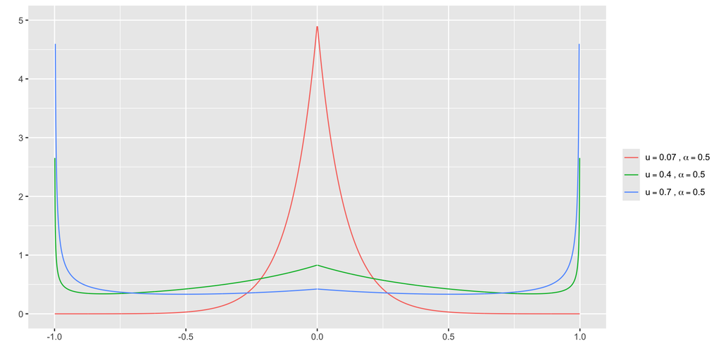

## AR1: Hyperparameters and prior

The AR1 model has two parameters

- The precision $\tau$
  - PC prior as before - Baseline $\tau=0$ `pc.prec`
    $$\text{Prob}(\sigma > u) = \alpha$$
- The autocorrelation (or persistence) parameter $(-1,1)
  - Two choices of PC priors
2. Baseline $\phi = 1$ `pc.cor1`

$$\begin{eqnarray}
\text{Prob}(\rho > u) = \alpha;&\\
-1<u<1;\qquad &\sqrt{\frac{1-u}{2}}<\alpha<1
\end{eqnarray}$$

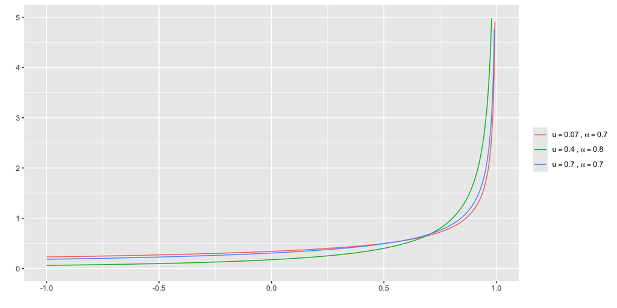

## Example - AR1 and RW1 for earthquakes data

**The Model**

$$\begin{aligned}
y_t|\eta_t & \sim \text{Poisson}(\exp(\eta_t))\\
\eta_t & = \beta_0 + u_t\\
1.\ u_t&\sim \text{RW}1(\tau)\\
2.\ u_t&\sim \text{AR}1(\tau, \phi)\\
\end{aligned}$$

Number of serious earthquakes per year

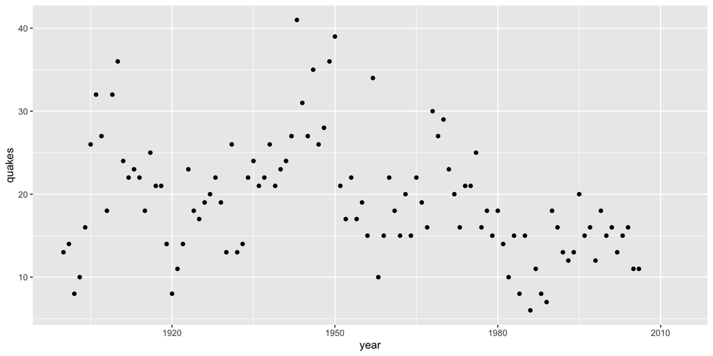

```r
hyper = list(prec = list(prior = "pc.prec", param = c(1,0.5)))
cmp1 = ~ Intercept(1) + time(year, model = "rw1", scale.model = T,
                             hyper = hyper)
cmp2 = ~ Intercept(1) + time(year, model = "ar1",
                             hyper = hyper)


lik = bru_obs(formula = quakes ~ .,
              family = "poisson",
              data = df)

fit1 = bru(cmp1, lik)
fit2 = bru(cmp2, lik)
```

## Example - RW1 and AR1

Estimated trend

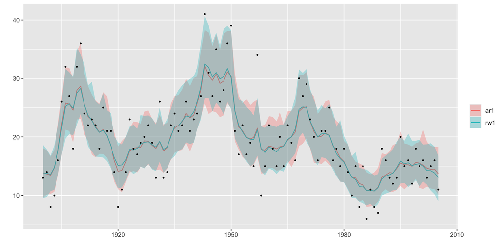

## Example - RW1 and AR1

Predictions

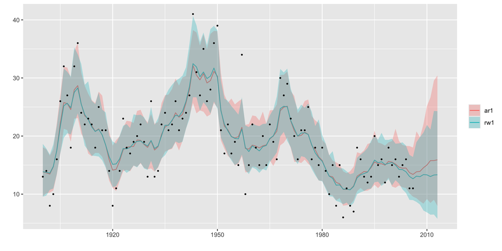

## AR1 vs. RW models

- RW1 models can be seen as a limit for AR1 models
- They are not too different when smoothing, but can give different predictions.

# Continuous time modelling

## Continuous time modelling

- Sometimes the data are not collected at discrete time points but over continuous time
- One solution (not a bad one usually) is to discretize the time and use RW model (AR models are then harder to justify..)
- A different solution is to use a continuous smoother based on a continuous Gaussian Random Field (GRF) $\omega(t)$

What is this?

- It is a process defined everywhere in the time domain $\mathcal{T}$ such that, if i take $n$ points $t_1,t_2,\dots,t_n$ then

$$(\omega(t_1),\omega(t_2),\dots,\omega(t_n))\sim\mathcal{N}(\mathbf{0},\mathbf{\Sigma}_{\omega(t_1),\omega(t_2),\dots,\omega(t_n)} ), \qquad \text{ for any } t_1,t_2,\dots,t_n\in\mathcal{T}$$
Where $\mathbf{\Sigma}_{\omega(t_1),\omega(t_2),\dots,\omega(t_n)}$ is a variance-covariance matrix.

To define $\omega(t), t\in\mathcal{T}$, we have to define $\Sigma$

BUT…

Covariance matrices are not nice objects!

- Hard to define
- Dense
- computationally hard to deal with

## The SPDE approach

We define a (Matérn) GRF as the solution of a stochastic partial differential equation (SPDE)

$$(\kappa^2-\Delta)^{\alpha/2}\omega(t) = W(t)$$

What is this?

- $W(t)$ is random noise
- $\omega(t)$ is the smooth process we want
- $(\kappa^2-\Delta)^{\alpha/2}$ is an operator that “smoothes” the white noise.
- $\kappa$ and $\alpha$ are parameters

## One analogy..

- Think of white noise as someone randomly tapping along a rope.
  - The taps are independent.
  - Some are big, some are small.
  - They have no relation to each other.
  - This is just like White noise!
- But the rope has tension and stiffness
  - the tension spreads each tap to nearby points.
  - Sharp jumps are softened.
- The rope settles into a smooth wiggly shape (just like a Matérn field!)

The parameters:

- Tension = controls how far randomness propagates ($\kappa$)
- Stiffness = controls how smooth the field becomes ($\alpha$)

## SPDE as a smoothing operator

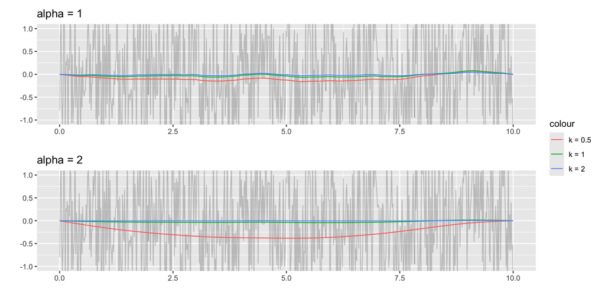

## Solving the SPDE

Ok…but we still need to solve the SPDE to find $\omega(t)$!

Now we need to discretize the domain into T points (we cannot compute on the continuous!)

We represent our solution as

$$\omega(t) = \sum_{i = 1}^T\phi_i(t)w_i$$

Where

- $\phi_i(s)$ are (known) basis functions
- $w_i$ are (unknown) weights

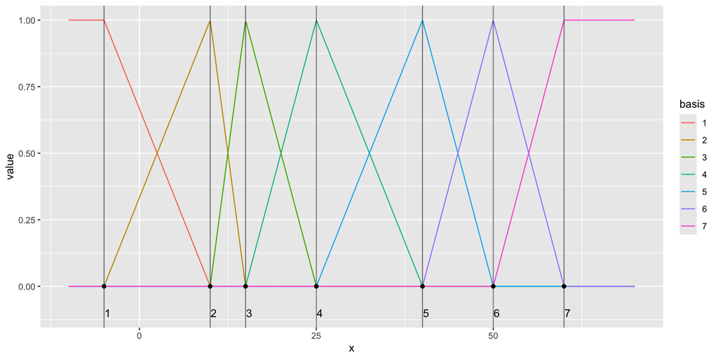

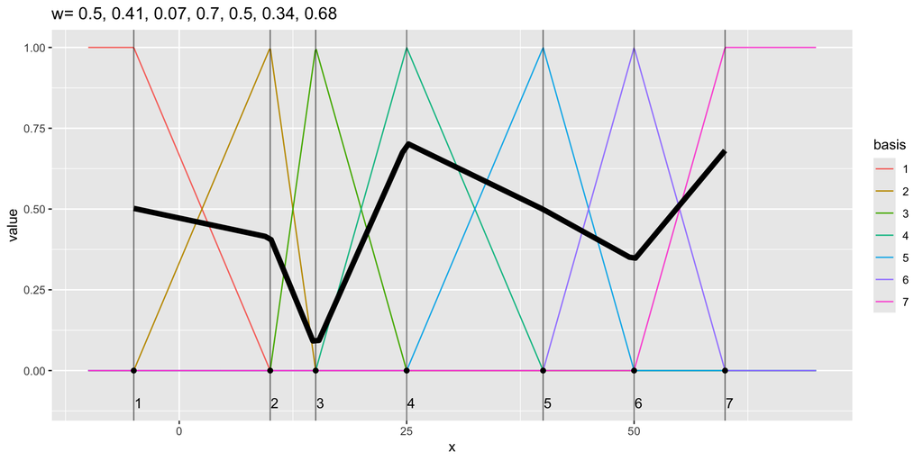

## In summary

- The continuous Matérn GRF is the solution of an SPDE and is represented as

$$\omega(t) = \sum_{i = 1}^T\phi_i(t)w_i$$

- The weights vector $\mathbf{w} = (w_1,\dots,w_N)$ is Gaussian with a **sparse** precision matrix $\longrightarrow$ Computational convenience
- The field has two parameters
  - The range $\rho$
  - The marginal variance $\sigma^2$
- These parameters are linked to the parameters of the SPDE
- We need to assign prior to them

## PC priors for range and marginal variance

Remember:

- PC priors penalize distance from a basis model
- Are expressed in a user friendly way

For the **range** we have:
$$\text{Prob}(\rho<\rho_0) = p_{\rho}$$

For the **marginal standard deviation** we have:
$$\text{Prob}(\sigma > \sigma_0) = p_{\sigma}$$

## PC priors for range and marginal variance

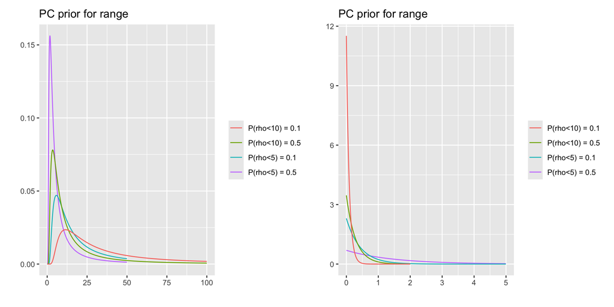

## In practice…

If you want to use a continous model for time (or for smoothing a covariate) you need to:

1. Define a 1-dimensional mesh over the domain of interest (allowing for some buffer around your domain)
- How many nodes?
- Where to place them?

```r
# domain of interest 0-10
locs = seq(-3,13,1)
mesh1d = fm_mesh_1d(locs, degree = 1, boundary = "neumann")
```

2. Define the SPDE model and the prior

```r
spde <- inla.spde2.pcmatern(mesh1d,
  prior.range = c(10, 0.5), # Prob(range<10) = 0.5
  prior.sigma = c(1, 0.5)   # Prob(sd>1) = 0.5
)
```

3. Use the SPDE model in a component of your model

```r
cmp = ~ Intercept(1) + smooth(covariate, model = spde)
```

## Example

Let’s go back to the Triceps skinfold thickness example.

**The Model**

$$\begin{aligned}
y_i|\eta_i, \sigma^2 & \sim \mathcal{N}(\eta_i,\sigma^2)\\
\eta_i & = \beta_0 + \omega(\text{age}_i)\\
\omega(\text{age}_i) & \sim \text{GF}(\rho_{\omega},\sigma_{\omega})
\end{aligned}$$

```r
triceps = read_csv("Data/triceps.csv")
triceps[1:3,c(1,3)]
```

```
# A tibble: 3 × 2
    age triceps
  <dbl>   <dbl>
1 12.1     3.40
2  9.91    4
3 10.0     4.20
```

**The code**

```r
#|
locs = seq(-5,60,5)
mesh1d = fm_mesh_1d(locs, degree = 2, boundary = "neumann")

spde <- inla.spde2.pcmatern(mesh1d,
  prior.range = c(10, 0.5),
  prior.sigma = c(1, 0.5))

cmp <- ~ Intercept(1) +  field(age, model = spde)
lik_spde = bru_obs(formula = triceps ~.,data = triceps)
fit_spde = bru(cmp, lik_spde)
```

## Comparing SPDE and RW2

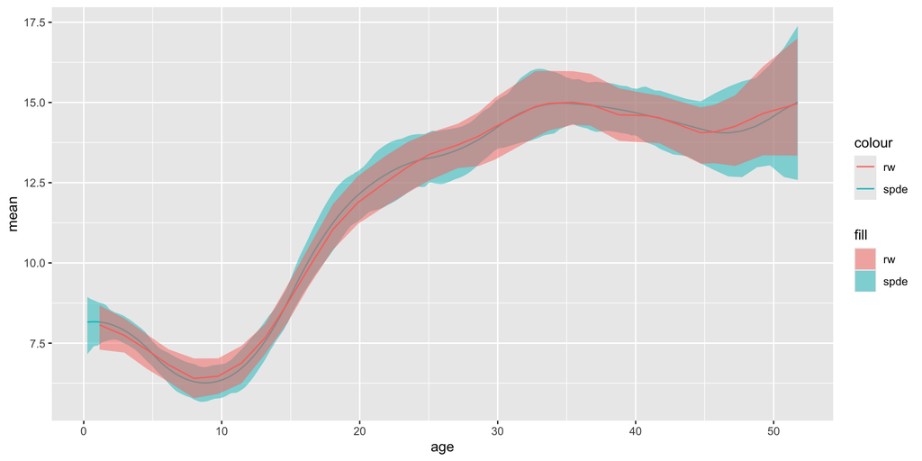